# Week 6, Analysis of longitudinal data

This week’s exercise is about repeated measures analysis. Tasks include:

- Data exploration
- Analysis of longitudinal data ignoring the longitudinal nature
- Analysis of longitudinal data
  - Summary Measure Analysis of Longitudinal Data
  - Random Intercept Model
  - Random Intercept and Random Slope Model
  - Random Intercept and Random Slope Model with interaction
- Model comparison
- Plotting

## 0. Starting routines

Setting working path, loading library and data set.

```r
#Setting working path
setwd("/home/ls/R/projekteja/IODS-project/")
```

According to instructions, we are going to implement  
* the analyses of Chapter 8 of MABS using the RATS data  
* the analyses of Chapter 9 of MABS using the BPRS data.

## 1. DM and data exploration (RATS)

RATS data is from a nutrition study conducted in three groups of rats (*Crowder and Hand*, 1990), where weights of rats has been measured several times.

```r
#Reading datasets from the files
RATSL <- read.table("./data/RATSL.rData")
str(RATSL)
```

```
## 'data.frame':    176 obs. of  5 variables:
##  $ ID    : int  1 2 3 4 5 6 7 8 9 10 ...
##  $ Group : int  1 1 1 1 1 1 1 1 2 2 ...
##  $ WD    : Factor w/ 11 levels "WD1","WD15","WD22",..: 1 1 1 1 1 1 1 1 1 1 ...
##  $ Weight: int  240 225 245 260 255 260 275 245 410 405 ...
##  $ Time  : int  1 1 1 1 1 1 1 1 1 1 ...
```

```r
RATSL$ID        <- factor(RATSL$ID)
RATSL$Group     <- factor(RATSL$Group)
```

```r
library(ggplot2)
library(dplyr)
table(RATSL$Group, RATSL$ID)
```

```
##
##      1  2  3  4  5  6  7  8  9 10 11 12 13 14 15 16
##   1 11 11 11 11 11 11 11 11  0  0  0  0  0  0  0  0
##   2  0  0  0  0  0  0  0  0 11 11 11 11  0  0  0  0
##   3  0  0  0  0  0  0  0  0  0  0  0  0 11 11 11 11
```

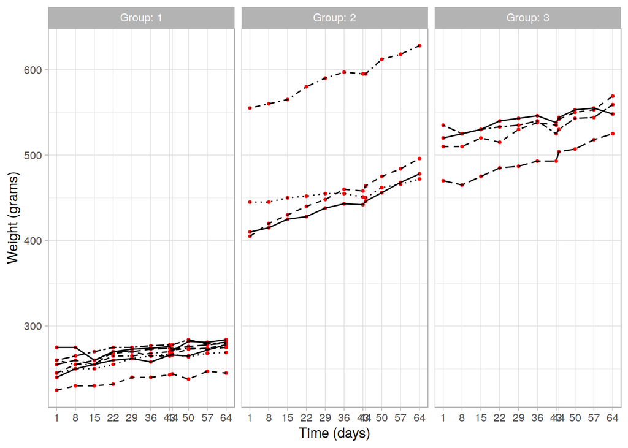

```r
timelevels <- RATSL$Time %>% unique()

# Draw the plot (original values)
ggplot(RATSL, aes(x = Time, y = Weight, linetype = ID)) +
  geom_point(shape="circle", color="red", size=0.75) +
  geom_line() +
  scale_linetype_manual(values = rep(1:8, times=10)) +
  facet_grid(. ~ Group, labeller = label_both) +
  theme_light() +
  theme(legend.position = "none") +
  scale_x_continuous(name="Time (days)", breaks=timelevels, minor_breaks=NULL) +
  scale_y_continuous(name="Weight (grams)", limits = c(min(RATSL$Weight), max(RATSL$Weight)))
```

From the ID*Time cross tabulation we can see that each ID has 11 observations in the long form data, i.e. each value is non-missing. Eight rats are in group 1, 4 in group 2 and 4 group 3.

## 2. Standardization (RATS)

Quote from Data Camp:

*An important effect we want to take notice is how the subjects who have higher BPRS values at the beginning tend to have higher values throughout the study. This phenomenon is generally referred to as tracking.*

In this context tracking would mean that rats having high weight at beginning tend to have high values in future as well. This sounds plausible feature for such measure as weight.

Let’s plot standardized values using the formula

$standardised(x) = \frac{x - mean(x)}{ sd(x)}$

This lets us easier observe possible tracking.

```r
# Standardise rat weight
RATSL <- RATSL %>%
  group_by(Time) %>%
  mutate(Weight_std = (Weight-mean(Weight))/sd(Weight)) %>%
  ungroup()

# Glimpse the data
glimpse(RATSL)
```

```
## Rows: 176
## Columns: 6
## $ ID         <fct> 1, 2, 3, 4, 5, 6, 7, 8, 9, 10, 11, 12, 13, 14, 15, 16, 1, …
## $ Group      <fct> 1, 1, 1, 1, 1, 1, 1, 1, 2, 2, 2, 2, 3, 3, 3, 3, 1, 1, 1, 1…
## $ WD         <fct> WD1, WD1, WD1, WD1, WD1, WD1, WD1, WD1, WD1, WD1, WD1, WD1…
## $ Weight     <int> 240, 225, 245, 260, 255, 260, 275, 245, 410, 405, 445, 555…
## $ Time       <int> 1, 1, 1, 1, 1, 1, 1, 1, 1, 1, 1, 1, 1, 1, 1, 1, 8, 8, 8, 8…
## $ Weight_std <dbl> -1.0011429, -1.1203857, -0.9613953, -0.8421525, -0.8819001…
```

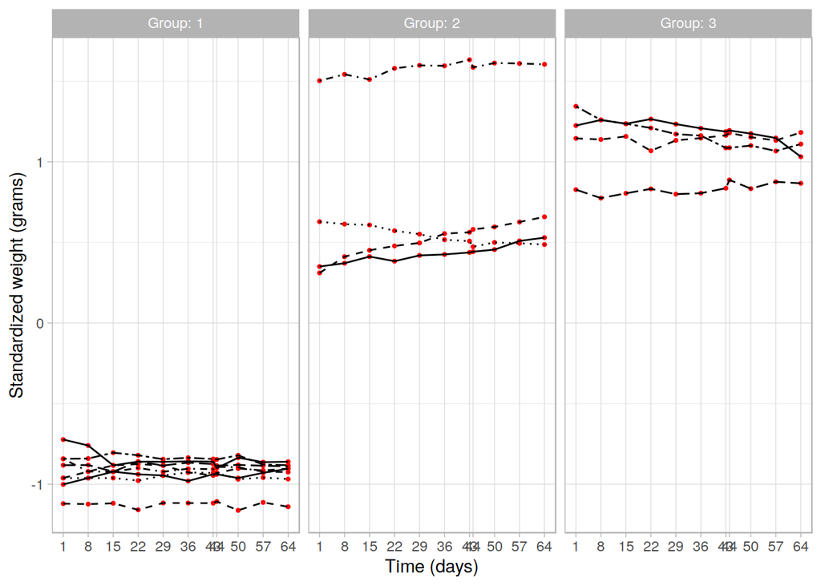

```r
# Plot again with the standardised bprs
ggplot(RATSL, aes(x = Time, y = Weight_std, linetype = ID)) +
  geom_point(shape="circle", color="red", size=0.75) +
  geom_line() +
  scale_linetype_manual(values = rep(1:8, times=10)) +
  facet_grid(. ~ Group, labeller = label_both) +
  theme_light() +
  theme(legend.position = "none") +
  scale_x_continuous(name="Time (days)", breaks=timelevels, minor_breaks=NULL) +
  scale_y_continuous(name="Standardized weight (grams)", limits = c(min(RATSL$Weight_std), max(RATSL$Weight_std)))
```

Lines created from standardized values are more stationary. Tracking effect can be seen clearly, values of the same rat mostly remains at fixed level.

### Mean response profiles

```r
# Number of subjects
# Probably this is supposed to be a group n, so this is not correct.
n <- RATSL$ID %>% unique() %>% length()

# Summary data with mean and standard error of bprs by treatment and week
RATSS <- RATSL %>%
  group_by(Group, Time) %>%
  summarise( mean = mean(Weight), se = sd(Weight)/sqrt(n) ) %>%
  ungroup()
# Glimpse the data
glimpse(RATSS)
```

```
## Rows: 33
## Columns: 4
## $ Group <fct> 1, 1, 1, 1, 1, 1, 1, 1, 1, 1, 1, 2, 2, 2, 2, 2, 2, 2, 2, 2, 2, …
## $ Time  <int> 1, 8, 15, 22, 29, 36, 43, 44, 50, 57, 64, 1, 8, 15, 22, 29, 36,…
## $ mean  <dbl> 250.625, 255.000, 254.375, 261.875, 264.625, 265.000, 267.375, …
## $ se    <dbl> 3.805394, 3.273268, 2.868977, 3.400204, 2.764370, 2.945942, 2.7…
```

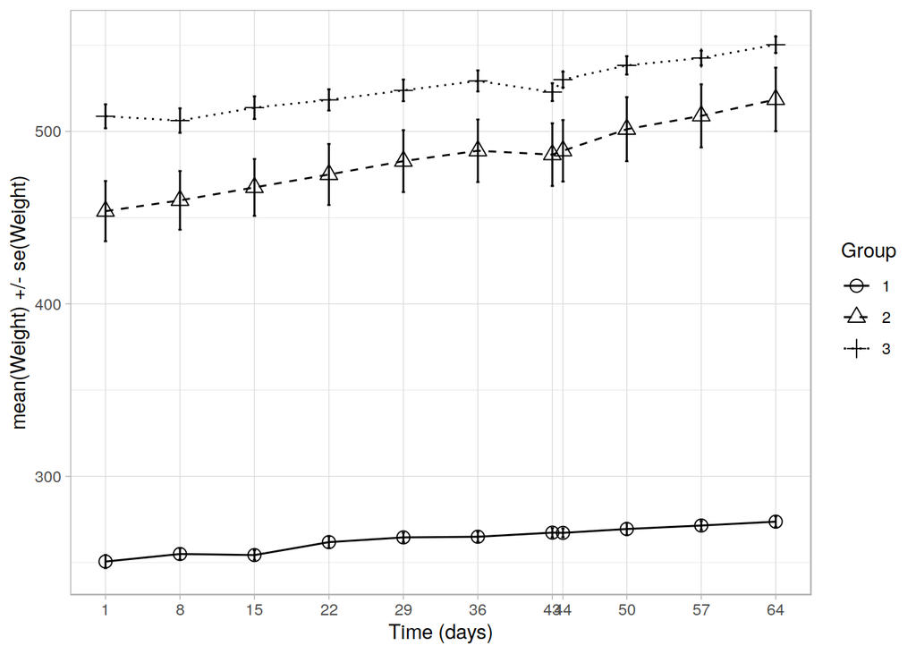

```r
# Plot the mean profiles
ggplot(RATSS, aes(x = Time, y = mean, linetype = Group, shape = Group)) +
  geom_line() +
  theme_light() +
  scale_linetype_manual(values = c(1,2,3)) +
  geom_point(size=3) +
  scale_shape_manual(values = c(1,2,3)) +
  geom_errorbar(aes(ymin = mean - se, ymax = mean + se, linetype="1"), width=0.3) +
  scale_x_continuous(name="Time (days)", breaks=timelevels, minor_breaks=NULL) +
  scale_y_continuous(name = "mean(Weight) +/- se(Weight)")
```

Plot shows as that each group has distinct level of Weight. Group 1 has lower values, but groups 2 & 3 seem to differ from each other as well. Group 2 has highest variation, shown as standard errors of the means here, group 1 variation is very low. In each group, mean weight is mainly growing and ends up to higher level that at the beginning. My guess is that with Repeated measures ANOVA and all time points Time would statistically significant factor, Group as well but not Time * Group interaction.

## 3. Summary Measure Analysis of Longitudinal Data (RATS)

Quote from MABS book: *“The summary measure method operates by transforming the repeated measurements made on each individual in the study into a single value that captures some essential feature of the individual’s response over time. Analysis then proceeds by applying standard univariate methods to the summary measures from the sample of subjects (see later examples). The approach has been in use for many years, and is described in Oldham (1962), Yates (1982) and Matthews et al. (1990).”*

We need to follow book analyses. Let’s start with box plots before we do more.

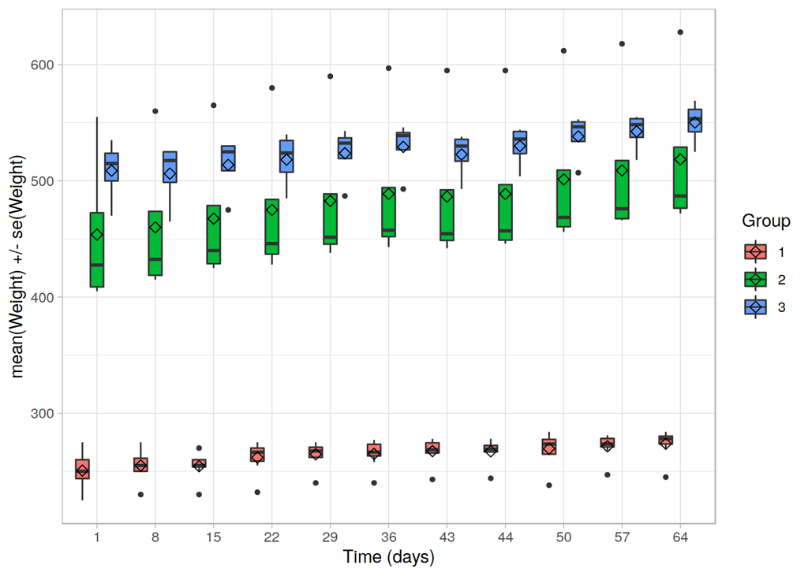

```r
# Plot the mean profiles
ggplot(RATSL, aes(x=as.factor(Time), y=Weight, fill=Group)) +
  geom_boxplot(outlier.size=1) +
  stat_summary(fun="mean", geom="point", shape=5, size=2, position=position_dodge(width=0.75),color="black") +
  theme_light() +
  scale_x_discrete(name="Time (days)", breaks=timelevels) +
  scale_y_continuous(name = "mean(Weight) +/- se(Weight)")
```

Diamonds are indicating group means values at that specific time point. Please note that x-axis is not in absolute scale anymore!

### Applying the Summary Measure Approach

To mimic analyses in MABS book, let’s apply summary measure approach to all weight values after 1st day of diet. The mean of days 8 to 64 will be then chosen summary measure. We’ll first calculate this measure and then look at boxplots of the measure for each treatment group. The resulting plot is shown soon.

```r
RATL64S <- RATSL %>%
  filter(Time > 1) %>%
  group_by(Group, ID) %>%
  summarise(mean=mean(Weight) ) %>%
  ungroup()
glimpse(RATL64S)
```

```
## Rows: 16
## Columns: 3
## $ Group <fct> 1, 1, 1, 1, 1, 1, 1, 1, 2, 2, 2, 2, 3, 3, 3, 3
## $ ID    <fct> 1, 2, 3, 4, 5, 6, 7, 8, 9, 10, 11, 12, 13, 14, 15, 16
## $ mean  <dbl> 263.2, 238.9, 261.7, 267.2, 270.9, 276.2, 274.6, 267.5, 443.9, …
```

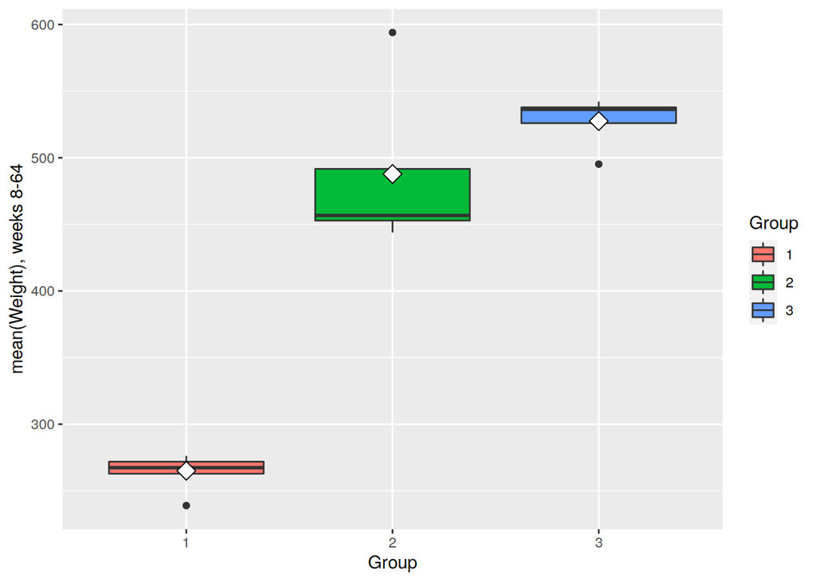

```r
# Draw a boxplot of the mean versus treatment
ggplot(RATL64S, aes(x=Group, y=mean, fill=Group)) +
  geom_boxplot() +
  stat_summary(fun="mean", geom="point", shape=23, size=4, fill="white") +
  scale_y_continuous(name="mean(Weight), weeks 8-64")
```

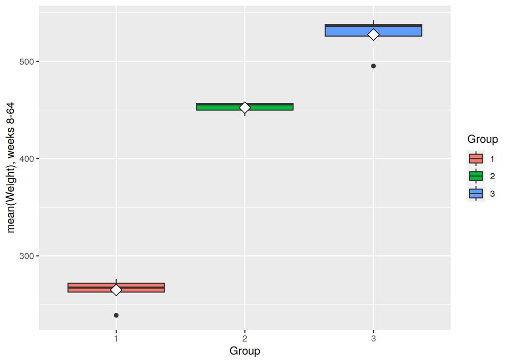

```r
# Create a new data by filtering the outlier and adjust the ggplot code the draw the plot again with the new data
RATL64S1 <- RATL64S %>%
  filter(mean < 550)

# Draw a boxplot of the mean versus treatment
ggplot(RATL64S1, aes(x=Group, y=mean, fill=Group)) +
  geom_boxplot() +
  stat_summary(fun="mean", geom="point", shape=23, size=4, fill="white") +
  scale_y_continuous(name="mean(Weight), weeks 8-64")
```

As was seen, single outlier mean value of ~600 was removed and plot was recreated. BTW, that high value was coming from rat #12 in group 2 and this rat is now removed from the analysis.

### One-Way ANOVA

```r
# Fit the linear model with the mean as the response
fit1 <- lm(mean ~ Group, data=RATL64S1)

# Compute the analysis of variance table for the fitted model with anova()
anova(fit1)
```

```
## Analysis of Variance Table
##
## Response: mean
##           Df Sum Sq Mean Sq F value    Pr(>F)
## Group      2 207659  103830  501.81 2.721e-12 ***
## Residuals 12   2483     207
## ---
## Signif. codes:  0 '***' 0.001 '**' 0.01 '*' 0.05 '.' 0.1 ' ' 1
```

```r
# Post-hoc comparisons, Tukey HSD
TukeyHSD(aov(lm(mean ~ Group, data = RATL64S1)))
```

```
##   Tukey multiple comparisons of means
##     95% family-wise confidence level
##
## Fit: aov(formula = lm(mean ~ Group, data = RATL64S1))
##
## $Group
##        diff       lwr      upr    p adj
## 2-1 187.375 161.39457 213.3554 0.00e+00
## 3-1 262.475 238.97481 285.9752 0.00e+00
## 3-2  75.100  45.79012 104.4099 4.98e-05
```

That was 1-way ANOVA, predicting rat’s mean weight value of days 8-64 in grams with diet group, with single rat excluded. ANOVA table shows that Group effect is statistically significant (p<0.001). Difference between at least two groups is statistically significant.

Pairwise comparisons (using Tukey’s HSD method) shows that each group differs statistically (p<0.001) from all other groups.

### One-Way ANCOVA

```r
# First we need to import original data
RATS <- read.csv("https://raw.githubusercontent.com/KimmoVehkalahti/MABS/master/Examples/data/rats.txt", sep="\t")

# Add the baseline from the original data as a new variable to the summary data
RATL64S2 <- RATL64S %>% mutate(Baseline = RATS$WD1)

# Fit the linear model with the mean as the response
fit2 <- lm(mean ~ Baseline + Group, data=RATL64S2)

# Compute the analysis of variance table for the fitted model with anova()
anova(fit2)
```

```
## Analysis of Variance Table
##
## Response: mean
##           Df Sum Sq Mean Sq   F value   Pr(>F)
## Baseline   1 253625  253625 1859.8201 1.57e-14 ***
## Group      2    879     439    3.2219  0.07586 .
## Residuals 12   1636     136
## ---
## Signif. codes:  0 '***' 0.001 '**' 0.01 '*' 0.05 '.' 0.1 ' ' 1
```

ANOVA table shows that Baseline level was statistically significant predictor for later mean weight. After controlling for baseline value, group effect wasn’t significant anymore (p=0.08).

## 4. DM and data exploration (BPRS)

Using dataset taken from Davis *(Davis, C. S. (2002). Statistical Methods for the Analysis of Repeated Measurements. Springer, New York.)*, where (Quote from MABS book) “40 male subjects were randomly assigned to one of two treatment groups and each subject was rated on the brief psychiatric rating scale (BPRS) measured before treatment began (week 0) and then at weekly intervals for eight weeks. The BPRS assesses the level of 18 symptom constructs such as hostility, suspiciousness, hallucinations and grandiosity; each of these is rated from one (not present) to seven (extremely severe). The scale is used to evaluate patients suspected of having schizophrenia.”

We need to change ID code to have unique values for each subject. Thanks to Jukke Kaaronen for pointing this out.

```r
#Reading datasets from the files
BPRSL <- read.table("./data/BPRSL.rData")

#New ID and varible roles
BPRSL$subject_old <- BPRSL$subject
BPRSL$subject     <- BPRSL$subject+(100*BPRSL$treatment)
BPRSL$treatment   <- factor(BPRSL$treatment)
BPRSL$subject     <- factor(BPRSL$subject)

str(BPRSL)
```

```
## 'data.frame':    360 obs. of  6 variables:
##  $ treatment  : Factor w/ 2 levels "1","2": 1 1 1 1 1 1 1 1 1 1 ...
##  $ subject    : Factor w/ 40 levels "101","102","103",..: 1 2 3 4 5 6 7 8 9 10 ...
##  $ weeks      : Factor w/ 9 levels "week0","week1",..: 1 1 1 1 1 1 1 1 1 1 ...
##  $ bprs       : int  42 58 54 55 72 48 71 30 41 57 ...
##  $ week       : int  0 0 0 0 0 0 0 0 0 0 ...
##  $ subject_old: int  1 2 3 4 5 6 7 8 9 10 ...
```

Now treatment group 1 has subject ID’s 101-120 and group 2 ID’s 201-220. Variable is *subject* while the original one is *subject_old*.

Data is in long form, we don’t need to transpose it.

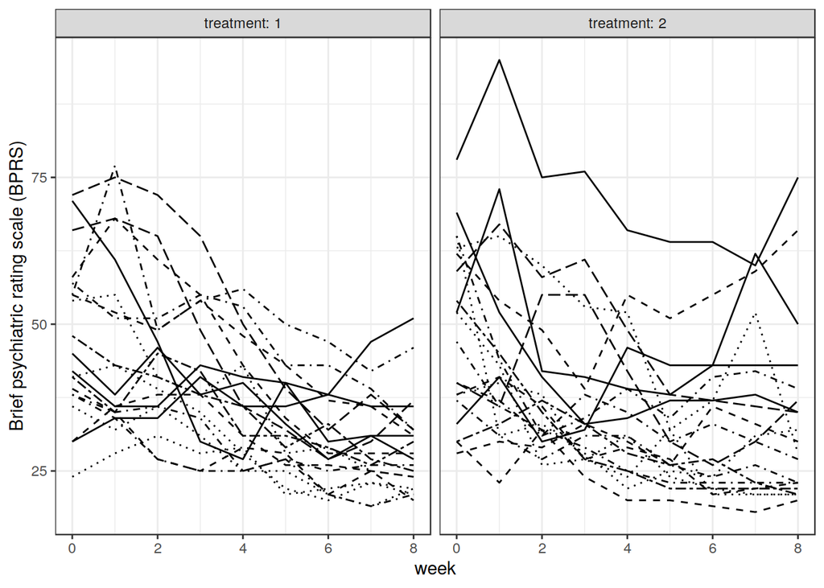

```r
#Spaghetti plot
ggplot(BPRSL, aes(x=week, y=bprs, linetype=subject)) +
  geom_line() +
  scale_linetype_manual(values = rep(1:10, times=4)) +
  facet_grid(. ~ treatment, labeller = label_both) +
  theme_bw() +
  theme(legend.position = "none") +
  scale_y_continuous(name = "Brief psychiatric rating scale (BPRS)")
```

“Spaghetti plot” shows lines for each subject and how BPRS values are changing over times. We can see that variance is high in both groups, values tend mostly decrease and there is not obvious mean difference between treatments.

```r
# Number of weeks, baseline (week 0) included
# Probably this is supposed to be a group n, so this is not correct.
n <- BPRSL$week %>% unique() %>% length()

# Summary data with mean and standard error of bprs by treatment and week
BPRSS <- BPRSL %>%
  group_by(treatment, week) %>%
  summarise( mean = mean(bprs), se = sd(bprs)/sqrt(n) ) %>%
  ungroup()
```

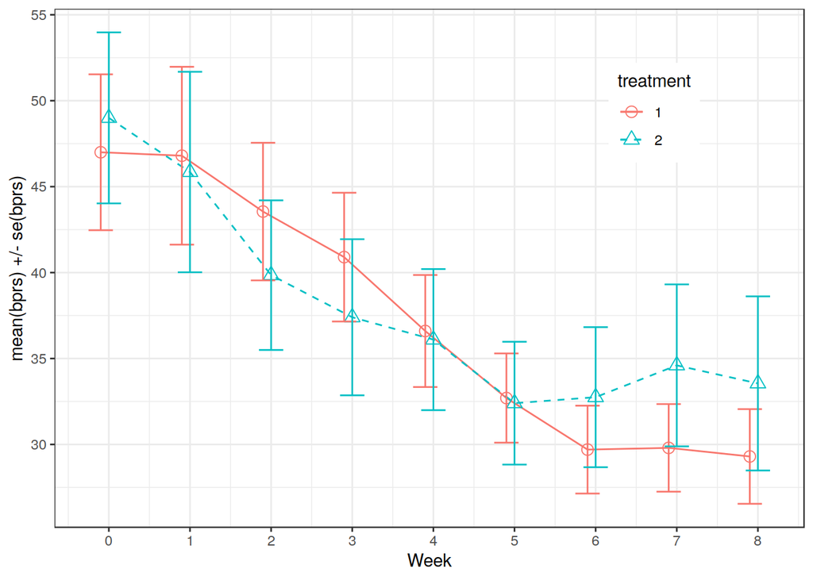

```r
#Mean profile plot
ggplot(BPRSS, aes(x = week+(0.1*(as.numeric(treatment)-2)), y = mean, linetype = treatment, shape = treatment, color=treatment)) +
  geom_line() +
  scale_linetype_manual(values = c(1,2)) +
  geom_point(size=3) +
  scale_shape_manual(values = c(1,2)) +
  geom_errorbar(aes(ymin = mean - se, ymax = mean + se, linetype="1"), width=0.3) +
  theme_bw() +
  theme(legend.position = c(0.8,0.8)) +
  scale_x_continuous(name = "Week", breaks=c(0:8)) +
  scale_y_continuous(name = "mean(bprs) +/- se(bprs)")
```

Mean profile plot with std.err.mean bars is useful. Now it indicates change in time (values are decreasing on average). Variance seems to be a bit lower at the end in group 1. There is no evident group difference, although gap slightly grows at the end.

## 5. Linear regresion model (BPRS)

Let’s first conduct basic linear model, which is not taking longitudinal nature of the data into account at all.

```r
# create a regression model RATS_reg
BPRS_reg <- lm(bprs ~ week + treatment, data=BPRSL)

# print out a summary of the model
summary(BPRS_reg)
```

```
##
## Call:
## lm(formula = bprs ~ week + treatment, data = BPRSL)
##
## Residuals:
##     Min      1Q  Median      3Q     Max
## -22.454  -8.965  -3.196   7.002  50.244
##
## Coefficients:
##             Estimate Std. Error t value Pr(>|t|)
## (Intercept)  46.4539     1.3670  33.982   <2e-16 ***
## week         -2.2704     0.2524  -8.995   <2e-16 ***
## treatment2    0.5722     1.3034   0.439    0.661
## ---
## Signif. codes:  0 '***' 0.001 '**' 0.01 '*' 0.05 '.' 0.1 ' ' 1
##
## Residual standard error: 12.37 on 357 degrees of freedom
## Multiple R-squared:  0.1851, Adjusted R-squared:  0.1806
## F-statistic: 40.55 on 2 and 357 DF,  p-value: < 2.2e-16
```

Summary table shows that week effect is statistically significant, group effect not. But within-subject correlation is not taken into account, so this is not reasonable analysis and we should pay more attention to it.

## 6. Linear Mixed Models (BPRS)

### The Random Intercept Model

```r
# access library lme4
library(lme4)
# Create a random intercept model
BPRS_ref <- lmer(bprs ~ week + treatment + (1 | subject), data = BPRSL, REML = FALSE)

# Print the summary of the model
summary(BPRS_ref)
```

```
## Linear mixed model fit by maximum likelihood  ['lmerMod']
## Formula: bprs ~ week + treatment + (1 | subject)
##    Data: BPRSL
##
##      AIC      BIC   logLik deviance df.resid
##   2582.9   2602.3  -1286.5   2572.9      355
##
## Scaled residuals:
##      Min       1Q   Median       3Q      Max
## -2.27506 -0.59909 -0.06104  0.44226  3.15835
##
## Random effects:
##  Groups   Name        Variance Std.Dev.
##  subject  (Intercept) 97.39    9.869
##  Residual             54.23    7.364
## Number of obs: 360, groups:  subject, 40
##
## Fixed effects:
##             Estimate Std. Error t value
## (Intercept)  46.4539     2.3521  19.750
## week         -2.2704     0.1503 -15.104
## treatment2    0.5722     3.2159   0.178
##
## Correlation of Fixed Effects:
##            (Intr) week
## week       -0.256
## treatment2 -0.684  0.000
```

Random intercept model contains explanatory variables *week* and *treatment*. Model allows the linear regression fit for each subject to differ in intercept from other subjects.

Subject random effect variance is high indicating the considerable variation in the intercepts of the regression fits of the individual subject growth profiles.

### Random Intercept and Random Slope Model

```r
# Create a random intercept and random slope model
BPRS_ref1 <- lmer(bprs ~ week + treatment + (week | subject), data = BPRSL, REML = FALSE)

# Print the summary of the model
summary(BPRS_ref1)
```

```
## Linear mixed model fit by maximum likelihood  ['lmerMod']
## Formula: bprs ~ week + treatment + (week | subject)
##    Data: BPRSL
##
##      AIC      BIC   logLik deviance df.resid
##   2523.2   2550.4  -1254.6   2509.2      353
##
## Scaled residuals:
##     Min      1Q  Median      3Q     Max
## -2.4655 -0.5150 -0.0920  0.4347  3.7353
##
## Random effects:
##  Groups   Name        Variance Std.Dev. Corr
##  subject  (Intercept) 167.827  12.955
##           week          2.331   1.527   -0.67
##  Residual              36.747   6.062
## Number of obs: 360, groups:  subject, 40
##
## Fixed effects:
##             Estimate Std. Error t value
## (Intercept)  45.9830     2.6470  17.372
## week         -2.2704     0.2713  -8.370
## treatment2    1.5139     3.1392   0.482
##
## Correlation of Fixed Effects:
##            (Intr) week
## week       -0.545
## treatment2 -0.593  0.000
```

```r
# perform an ANOVA test on the two models
anova(BPRS_ref1, BPRS_ref)
```

```
## Data: BPRSL
## Models:
## BPRS_ref: bprs ~ week + treatment + (1 | subject)
## BPRS_ref1: bprs ~ week + treatment + (week | subject)
##           npar    AIC    BIC  logLik deviance  Chisq Df Pr(>Chisq)
## BPRS_ref     5 2582.9 2602.3 -1286.5   2572.9
## BPRS_ref1    7 2523.2 2550.4 -1254.6   2509.2 63.663  2  1.499e-14 ***
## ---
## Signif. codes:  0 '***' 0.001 '**' 0.01 '*' 0.05 '.' 0.1 ' ' 1
```

### Random Intercept and Random Slope Model with interaction

```r
BPRS_ref2 <- lmer(bprs ~ week + treatment + (week | subject) + week*treatment, data = BPRSL, REML = FALSE)

# print a summary of the model
summary(BPRS_ref2)
```

```
## Linear mixed model fit by maximum likelihood  ['lmerMod']
## Formula: bprs ~ week + treatment + (week | subject) + week * treatment
##    Data: BPRSL
##
##      AIC      BIC   logLik deviance df.resid
##   2523.5   2554.5  -1253.7   2507.5      352
##
## Scaled residuals:
##     Min      1Q  Median      3Q     Max
## -2.4747 -0.5256 -0.0866  0.4435  3.7884
##
## Random effects:
##  Groups   Name        Variance Std.Dev. Corr
##  subject  (Intercept) 164.204  12.814
##           week          2.203   1.484   -0.66
##  Residual              36.748   6.062
## Number of obs: 360, groups:  subject, 40
##
## Fixed effects:
##                 Estimate Std. Error t value
## (Intercept)      47.8856     2.9840  16.047
## week             -2.6283     0.3752  -7.006
## treatment2       -2.2911     4.2200  -0.543
## week:treatment2   0.7158     0.5306   1.349
##
## Correlation of Fixed Effects:
##             (Intr) week   trtmn2
## week        -0.668
## treatment2  -0.707  0.473
## wek:trtmnt2  0.473 -0.707 -0.668
```

```r
# perform an ANOVA test on the two models
anova(BPRS_ref2, BPRS_ref1)
```

```
## Data: BPRSL
## Models:
## BPRS_ref1: bprs ~ week + treatment + (week | subject)
## BPRS_ref2: bprs ~ week + treatment + (week | subject) + week * treatment
##           npar    AIC    BIC  logLik deviance Chisq Df Pr(>Chisq)
## BPRS_ref1    7 2523.2 2550.4 -1254.6   2509.2
## BPRS_ref2    8 2523.5 2554.6 -1253.7   2507.5  1.78  1     0.1821
```

This was a random intercept and slope model which allows for a group × time (i.e. treatment x week) interaction.

Week effect is still statistically significant, but treatment effect is not, as well as interaction is not significant, not even close.

Earlier mean profile plot tells the same story. Different shape of mean curves would have been an indication for interaction. No there wasn’t such.

Likelihood ratio shows comparison of this one and previous model. Observerd significance level of 0.18 means interaction model is not providing a a better fit for this BPRS data. We should stick to random intercept and slope model.

### Fitted growth rate profiles from the interaction model and observed growth rate profiles.

As in MABS book, let’s plot observed values and predicted values from interaction model.

```r
library(ggpubr)    #for get_legend
library(gridExtra) #for multiple grobs
```

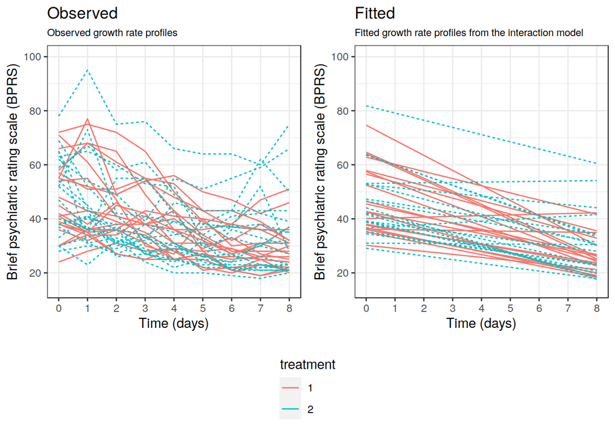

```r
# draw the plot of BPRS with the observed Weight values

p_dummy <- ggplot(BPRSL, aes(x=week, y=bprs, color=treatment)) +
  geom_line()

leg <- get_legend(p_dummy)

x_scale <- scale_x_continuous(name = "Time (days)", breaks=c(0:8), minor_breaks=NULL)
y_scale <- scale_y_continuous(name = "Brief psychiatric rating scale (BPRS)", limits=c(15,100), breaks=c(20,40,60,80,100))
teema <- theme(legend.position="none", plot.subtitle=element_text(size=rel(0.75)))

p_obs <- ggplot(BPRSL, aes(x=week, y=bprs, group=subject, color=treatment)) +
  geom_line(aes(linetype=treatment)) +
  theme_bw() +
  teema +
  labs(
     title="Observed",
     subtitle="Observed growth rate profiles"
     ) +
  x_scale +
  y_scale

# Create a vector of the fitted values
Fitted <- fitted(BPRS_ref2)

# Create a new column fitted to BPRSL
BPRSL$fitted <- Fitted

# draw the plot of BPRSL with the Fitted values of weight
p_fit <- ggplot(BPRSL, aes(x=week, y=fitted, group=subject, color=treatment)) +
  geom_line(aes(linetype=treatment)) +
  theme_bw() +
  teema +
  labs(
     title="Fitted",
     subtitle="Fitted growth rate profiles from the interaction model"
     ) +
  x_scale +
  y_scale

grid.arrange(
  arrangeGrob(p_obs,
              p_fit,
              nrow=1,
              ncol=2),
  padding=unit(1, "lines"),
  leg,
  nrow=2,
  heights=c(0.5,0.15))
```